# レポート課題3-1

学籍番号：2094572t  
氏名：木澤 祐人

## テーマ

2020年3月1日から2020年3月30日までの、全世界のCOVID-19の新規感染者数のデータを、  
一次関数および指数関数で近似し、  
その結果を比較・考察する。

## 準備

まず、Google Driveに格納されているデータを読み込むため，Google Colab からGoogle Driveを参照できるよう、マウント処理を行う。

その後、目的の作業フォルダに移動し、covid19.csv の存在を確認する。

```python
from google.colab import drive
drive.mount('/content/drive')
%cd /content/drive/'My Drive'/情報管理/03/
%ls
```

```
/content/drive/My Drive/情報管理/03
03_01_moving_average.ipynb        covid19.csv   report_03_01.ipynb
03_02_approximate_function.ipynb  energy.csv    report03_input.csv
03_03_correlation.ipynb           icecream.csv  sun.csv
convert_report.ipynb              kishou.csv
```

次に、データ処理に必要なライブラリをインポートする。

```python
import pandas as pd
import numpy as np
import matplotlib.pyplot as plt
```

最後に、

- pandasライブラリを用いてデータを読み込み、
- 各列をnumpyライブラリ用にndarray型データとして抽出する。

```python
csv_data = pd.read_csv('covid19.csv', encoding='SHIFT-JIS')
day = csv_data.loc[:, '日'].to_numpy()
data = csv_data.loc[:, '新規感染者数(全世界)'].to_numpy()
```

## 直線近似と曲線近似

まず、データを線形関数 y=ax+b で近似するため、その傾き a と切片 b を計算する関数linear_approxを以下のように定義する。

```python
def linear_approx(data):

  N = np.size(data)
  y = np.array(data)
  x = np.arange(N)

  xx = x * x
  xy = x * y

  bunbo = N * np.sum(xx) - np.sum(x)*np.sum(x)

  a = (N*np.sum(xy) - np.sum(x)*np.sum(y)) / bunbo
  b = (np.sum(xx)*np.sum(y) - np.sum(xy)*np.sum(x)) / bunbo

  return (a, b)
```

次に、データを指数関数 y=b exp(ax) で近似するため、その a と b を計算する関数curve_approxを以下のように定義する。

```python
def curve_approx(data):

  (a, b) = linear_approx(np.log(data))
  b = np.exp(b)

  return (a, b)
```

以上で定義した二つの関数を使って、データを直線及び曲線でそれぞれ近似する。  
その結果を実データとともにプロットすると次のようになる。

```
linear approximate function: y = 2423.864516x + -11370.802151
curve approximate function: y = 1835.002011 exp( 0.135585x )
```

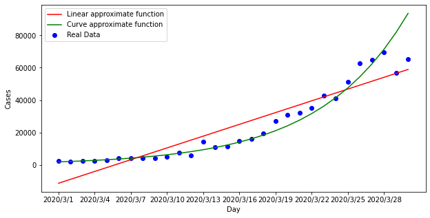

```python
# 関数の表示
(la, lb) = linear_approx(data)
print('linear approximate function: y = %fx + %f' % (la, lb))

(ca, cb) = curve_approx(data)
print('curve approximate function: y = %f exp( %fx )' % (cb, ca))

x = np.arange(np.size(data))
l_approx = la * x + lb
c_approx =  cb * np.exp(ca * x)

# データのプロット
plt.figure(figsize=(10,5))
plt.scatter(day, data, label='Real Data', color='b')
plt.plot(day, l_approx, label='Linear approximate function', color='r')
plt.plot(day, c_approx, label='Curve approximate function', color='g')
axis_array = np.arange(0, 30, step = 3 )
plt.xticks(axis_array)
plt.xlabel('Day')
plt.ylabel('Cases')
plt.legend()
plt.show()
```

２種類の近似が実際の値に対してどの程度ずれているのか調べるため、  
それぞれの平均二乗誤差と平均平方根二乗誤差を計算する。

```python
l_mse = np.mean((data - l_approx)*(data - l_approx))
l_rmse = np.sqrt(l_mse)

c_mse = np.mean((data - c_approx)*(data - c_approx))
c_rmse = np.sqrt(c_mse)


print("Linear approximation")
print('MSE = %f' % (l_mse))
print('RMSE = %f\n' % (l_rmse))

print("Curve approximation")
print('MSE = %f' % (c_mse))
print('RMSE = %f' % (c_rmse))
```

```
Linear approximation
MSE = 65021128.537061
RMSE = 8063.567978

Curve approximation
MSE = 56908363.946151
RMSE = 7543.763248
```

以上の結果から、線形近似の平均誤差は約8064人であったのに対し、曲線近似は平均で約7544人程度に抑えられており、  
今回のデータに関しては曲線近似の方がより高い精度で近似できると言える。